# Data Science in Practice Problem Set2

Group Members: Jingwei Chen, Ju-Hsuan Hsieh, Junze Li, Yuening Zhan, Yunbei Wang

## Outlines

- 1.Background
- 2.Data preparation
  - 2.1 Detect the NaN values
  - 2.2 Change the data type
  - 2.3 One-hot encoding
  - 2.4 Feature selection
  - 2.5 Train/Test set separation
- 3.Classification
  - 3.1 Logistic regression
  - 3.2 K-nearest neighbour
  - 3.3 Random forset
- 4.Model improvement
  - 4.1 Regularzation for logistic regression
  - 4.2 Grid search for K-NN
  - 4.3 Cross validation for random forest

```python
import numpy as np
import pandas as pd
import matplotlib.pyplot as plt
import seaborn as sns
import warnings
warnings.filterwarnings("ignore")
from sklearn.preprocessing import MinMaxScaler
from sklearn.decomposition import PCA
from sklearn.model_selection import train_test_split
from sklearn.linear_model import LogisticRegression
from sklearn.ensemble import RandomForestClassifier
from sklearn.model_selection import GridSearchCV
from sklearn.neighbors import KNeighborsClassifier
from sklearn.model_selection import cross_val_score
from sklearn.metrics import roc_curve, precision_recall_curve, auc, make_scorer, recall_score, accuracy_score, precision_score, f1_score, confusion_matrix,average_precision_score
```

### 1. Background

Customer churn is a term used especially in the world of subscription based businesses to describe loss of customers.

Churn is important because it directly affects your service's profitability. It is common to assume that the profitability of a service is directly related to the growth of its customer base. That might lead business owners to imply that in order to grow their customer base, the rate of acquiring new customers must exceed the churn rate.

In order to answers the questions "Are we losing customers?" and "If so, how?", our team made a Churn Analysis to support the Management to take action.

### 2. Data preparation

```python
customer_data = pd.read_csv('customers.csv')
```

```python
print('There are {} customer information in total.'.format(len(customer_data)))
```

```
There are 7043 customer information in total.
```

#### 2.1 Detect the NaN values

```python
customer_data["TotalCharges"] = customer_data["TotalCharges"].replace(" ", np.nan).astype('float32')
```

```python
customer_data = customer_data[customer_data["TotalCharges"].notnull()]
```

```python
print('There are {} customer information after data cleaning.'.format(len(customer_data)))
```

```
There are 7032 customer information after data cleaning.
```

#### 2.2 Change the data type

```python
customer_data["SeniorCitizen"] = customer_data["SeniorCitizen"].astype("object")
```

#### 2.3 One-hot encoding

```python
customer_data = customer_data.drop(columns = 'customerID', axis = 1)
```

```python
customer_data_dummy = customer_data.copy()
# convert categorical data to numerical data
# for binary category, convert them to '0', '1'

customer_data_dummy['Female'] = customer_data_dummy['gender'].apply(lambda x: 1 if x=='Female' else 0)
customer_data_dummy = customer_data_dummy.drop(columns='gender')
customer_data_dummy["Churn"] = customer_data_dummy['Churn'].map(lambda s :0  if s =='No' else 1)

customer_data_dummy['SeniorCitizen'] = customer_data_dummy['SeniorCitizen'].astype('int64')

# we regard the category 'no internet service' as 'no'
binary_cate = ['Partner', 'Dependents', 'PhoneService', 'MultipleLines', 'OnlineSecurity', 'OnlineBackup', 'DeviceProtection', 'TechSupport', 'StreamingTV', 'StreamingMovies', 'PaperlessBilling']
for cate in binary_cate:
    customer_data_dummy[cate] = customer_data_dummy[cate].apply(lambda x: 1 if x=='Yes' else 0)

# for the rest features, we use one-hot code
def dummies(col,df):
    dummies = pd.get_dummies(df[col], prefix=col)
    df = pd.concat([df, dummies], axis=1)
    df = df.drop(columns=col)
    return df

customer_data_dummy = dummies('InternetService', customer_data_dummy)
customer_data_dummy = dummies('Contract', customer_data_dummy)
customer_data_dummy = dummies('PaymentMethod', customer_data_dummy)
```

#### 2.4 Feature selection

```python
scaler = MinMaxScaler()
customer_data_scaled = pd.DataFrame(scaler.fit_transform(customer_data_dummy),columns=customer_data_dummy.columns)
```

```python
pca = PCA()
pca.fit(customer_data_scaled.drop(columns="Churn"))
```

```
PCA(copy=True, iterated_power='auto', n_components=None, random_state=None,
    svd_solver='auto', tol=0.0, whiten=False)
```

#### 2.5 Train/Test set separation

```python
X_train, X_test, y_train, y_test = train_test_split(customer_data_scaled.drop(columns="Churn"), customer_data_scaled["Churn"], test_size = 0.2, random_state = 10)
```

```python
X_train_sel = pca.transform(X_train)[:,range(15)]
X_test_sel = pca.transform(X_test)[:,range(15)]
```

```python
print('There are {} customer information in train set and {} in test set.'.format(len(X_train),len(X_test)))
```

```
There are 5625 customer information in train set and 1407 in test set.
```

### 3. Classification

```python
def plot_confusion_matrix(confusion_matrix):
    df_cm = pd.DataFrame(confusion_matrix, index=['Churn','No Churn'], columns=['Churn','No Churn'])
    fig = plt.figure(figsize=(7,5))
    heatmap = sns.heatmap(df_cm, annot=True, fmt="d", cmap='Greens')
    heatmap.yaxis.set_ticklabels(heatmap.yaxis.get_ticklabels(), rotation=0, ha='right', fontsize=12)
    heatmap.xaxis.set_ticklabels(heatmap.xaxis.get_ticklabels(), rotation=0, ha='right', fontsize=12)
    plt.ylim(0, 2)
    plt.title('The confusion matrix of the predicted results')
    plt.xlabel('Predicted label')
    plt.ylabel('True label')

def plot_roc_curve(fpr, tpr):
    print('The area under ROC curve is {}.'.format(auc(fpr, tpr)))
    plt.figure(figsize=(6,6))
    plt.title('The ROC Curve of classifier')
    plt.plot(fpr, tpr, linewidth=2)
    plt.plot([0, 1], [0, 1], 'k--')
    plt.axis([-0.005, 1, 0, 1.005])
    plt.xticks(np.arange(0,1, 0.1))
    plt.xlabel("False Positive Rate")
    plt.ylabel("True Positive Rate")
```

#### 3.1 Logistic Regression

```python
# train with original data
clf_lr = LogisticRegression(random_state=0).fit(X_train, y_train)
y_pred = clf_lr.predict(X_test)
cm_lr = confusion_matrix(y_test, y_pred, labels=[1,0])
y_score = clf_lr.decision_function(X_test)
fpr_lr, tpr_lr, auc_thresholds = roc_curve(y_test, y_score)

print("Accuracy Score:", accuracy_score(y_test, y_pred))
print("Recall Score:", recall_score(y_test, y_pred, labels=[1,0]))
print("Precision Score:", precision_score(y_test, y_pred, labels=[1,0]))
print("F1 Score:", f1_score(y_test, y_pred, labels=[1,0]))
```

```
Accuracy Score: 0.8088130774697939
Recall Score: 0.5761772853185596
Precision Score: 0.6419753086419753
F1 Score: 0.6072992700729927
```

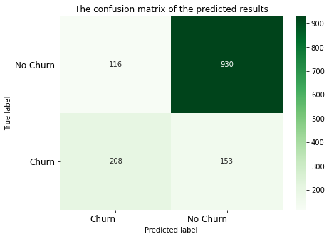

```python
plot_confusion_matrix(cm_lr)
```

```
The area under ROC curve is 0.8564720899561977.
```

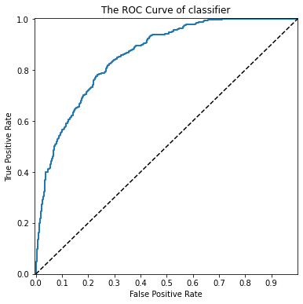

```python
plot_roc_curve(fpr_lr,tpr_lr)
```

```python
# train with feature selected data
clf_lr = LogisticRegression(random_state=10).fit(X_train_sel, y_train)
y_pred_sel = clf_lr.predict(X_test_sel)
cm_lr = confusion_matrix(y_test, y_pred_sel, labels=[1,0])

print("Accuracy Score:", accuracy_score(y_test, y_pred_sel))
print("Recall Score:", recall_score(y_test, y_pred_sel, labels=[1,0]))
print("Precision Score:", precision_score(y_test, y_pred_sel, labels=[1,0]))
print("F1 Score:", f1_score(y_test, y_pred_sel, labels=[1,0]))
```

```
Accuracy Score: 0.8031272210376688
Recall Score: 0.5290858725761773
Precision Score: 0.6409395973154363
F1 Score: 0.5796661608497724
```

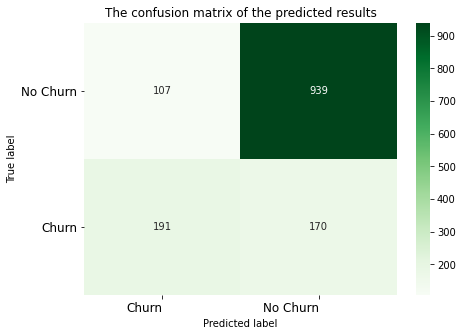

```python
plot_confusion_matrix(cm_lr)
```

#### 3.2 K-nearest neighbour

```python
# train with original data
clf_knn = KNeighborsClassifier(n_neighbors=45).fit(X_train, y_train)
y_pred = clf_knn.predict(X_test)
cm_knn = confusion_matrix(y_test, y_pred, labels=[1,0])
y_scores = clf_knn.predict_proba(X_test)
fpr_knn, tpr_knn, threshold = roc_curve(y_test, y_scores[:, 1])

print("Accuracy Score:", accuracy_score(y_test, y_pred))
print("Recall Score:", recall_score(y_test, y_pred, labels=[1,0]))
print("Precision Score:", precision_score(y_test, y_pred, labels=[1,0]))
print("F1 Score:", f1_score(y_test, y_pred, labels=[1,0]))
```

```
Accuracy Score: 0.8031272210376688
Recall Score: 0.6149584487534626
Precision Score: 0.6166666666666667
F1 Score: 0.6158113730929266
```

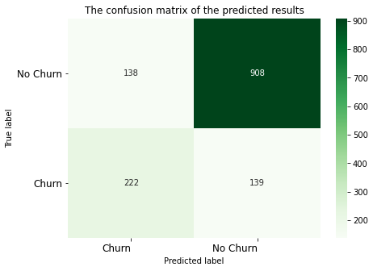

```python
plot_confusion_matrix(cm_knn)
```

```
The area under ROC curve is 0.8475620090782457.
```

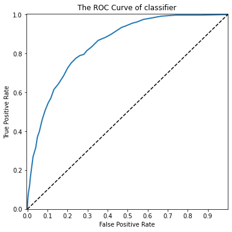

```python
plot_roc_curve(fpr_knn,tpr_knn)
```

```python
# train with feature selected data
clf2_knn = KNeighborsClassifier(n_neighbors=45).fit(X_train_sel, y_train)
y_pred_sel_knn = clf2_knn.predict(X_test_sel)
cm2_knn = confusion_matrix(y_test, y_pred_sel_knn, labels=[1,0])

print("Accuracy Score:", accuracy_score(y_test, y_pred_sel_knn))
print("Recall Score:", recall_score(y_test, y_pred_sel_knn, labels=[1,0]))
print("Precision Score:", precision_score(y_test, y_pred_sel_knn, labels=[1,0]))
print("F1 Score:", f1_score(y_test, y_pred_sel_knn, labels=[1,0]))
```

```
Accuracy Score: 0.7874911158493249
Recall Score: 0.5373961218836565
Precision Score: 0.5950920245398773
F1 Score: 0.5647743813682679
```

#### 3.3 Random forest

```python
# hyper parameters
hyper_params = {
                'n_estimators': 150,
                'criterion': 'gini',
                'class_weight': 'balanced',
                'max_depth': 10,
                'max_features': 'log2',
                'min_samples_leaf': 8,
                'min_samples_split': 2,
                'bootstrap': True,
                'oob_score': True
               }
```

```python
# define model
definedClassfier = RandomForestClassifier(n_jobs=-1, random_state=10, **hyper_params)
```

```python
# train with all features
clf_rf = definedClassfier.fit(X_train, y_train)
y_pred = clf_rf.predict(X_test)
cm_rf = confusion_matrix(y_test, y_pred, labels=[1,0])
y_score = clf_rf.predict_proba(X_test)[:,1]
fpr_rf, tpr_rf, auc_thresholds = roc_curve(y_test, y_score)

print("Accuracy Score:", accuracy_score(y_test, y_pred))
print("Recall Score:", recall_score(y_test, y_pred, labels=[1,0]))
print("Precision Score:", precision_score(y_test, y_pred, labels=[1,0]))
print("F1 Score:", f1_score(y_test, y_pred, labels=[1,0]))
```

```
Accuracy Score: 0.7647476901208244
Recall Score: 0.7922437673130194
Precision Score: 0.5276752767527675
F1 Score: 0.6334440753045404
```

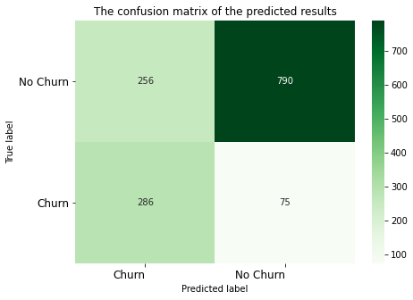

```python
plot_confusion_matrix(cm_rf)
```

```
The area under ROC curve is 0.8564720899561977.
```

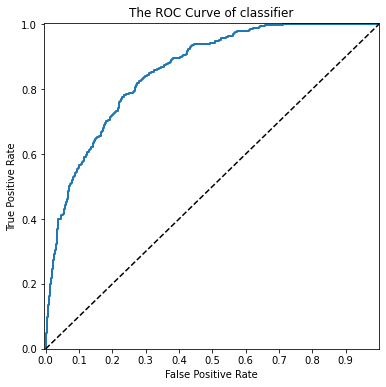

```python
plot_roc_curve(fpr_lr,tpr_lr)
```

```
<function matplotlib.pyplot.tight_layout(pad=1.08, h_pad=None, w_pad=None, rect=None)>
```

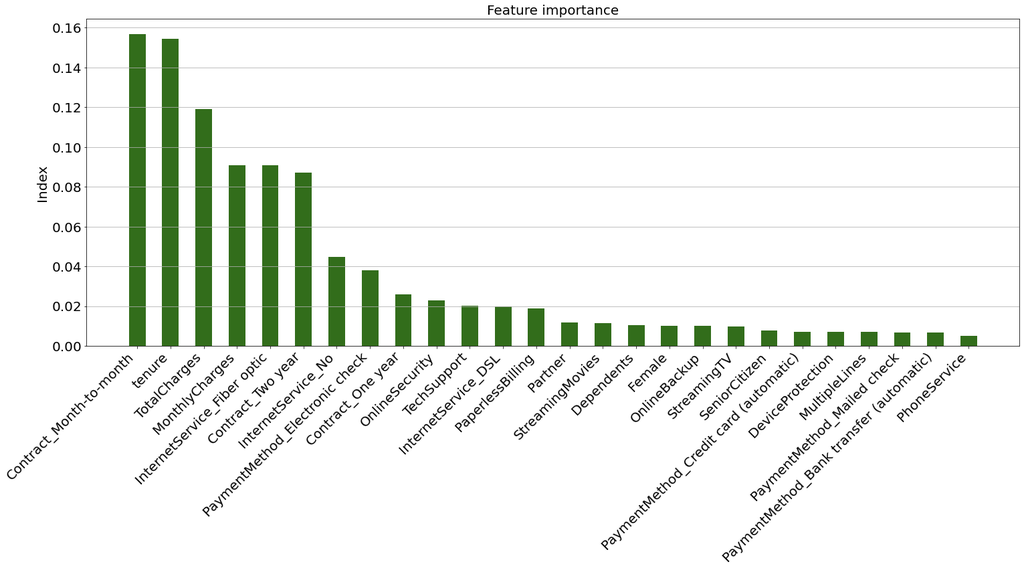

```python
# plot feature importance
feature_importance = pd.DataFrame(clf_rf.feature_importances_, index=X_train.columns, columns=['Weight'])
feature_importance = feature_importance.sort_values(by = 'Weight', ascending=False)
fig, ax = plt.subplots(figsize = (25, 9))
ax.set_title('Feature importance', fontsize = 20)
ax.tick_params(labelsize = 20)
# ax.set_xlabel('Features', fontsize = 20)
ax.set_ylabel('Index', fontsize = 20)
ax.grid(axis = 'y')
ax.bar(feature_importance.index, feature_importance['Weight'], width = 0.5, color = [50/255, 109/255, 27/255])
plt.xticks(np.arange(len(feature_importance)),feature_importance.index,rotation = 45, fontsize = 20,ha='right')
plt.tight_layout
```

```python
feature_index = np.argsort(clf_rf.feature_importances_)
feature_index = feature_index[-1::-1]
```

```python
# train with important features
X_train_sel = X_train.iloc[:, feature_index[:20]]
X_test_sel = X_test.iloc[:, feature_index[:20]]
print('Dropped features:', end=' ')
dropped = X_train.columns[feature_index[20:]]
for i in dropped:
    print(i, end = '; ')
print('\n')
clf_rf_sel = definedClassfier.fit(X_train_sel, y_train)
y_pred = clf_rf_sel.predict(X_test_sel)
cm_rf = confusion_matrix(y_test, y_pred, labels=[1,0])
y_score = clf_rf_sel.predict_proba(X_test_sel)[:,1]
fpr_rf, tpr_rf, auc_thresholds = roc_curve(y_test, y_score)

print("Accuracy Score:", accuracy_score(y_test, y_pred))
print("Recall Score:", recall_score(y_test, y_pred, labels=[1,0]))
print("Precision Score:", precision_score(y_test, y_pred, labels=[1,0]))
print("F1 Score:", f1_score(y_test, y_pred, labels=[1,0]))
```

```
Dropped features: PaymentMethod_Credit card (automatic); DeviceProtection; MultipleLines; PaymentMethod_Mailed check; PaymentMethod_Bank transfer (automatic); PhoneService;

Accuracy Score: 0.7654584221748401
Recall Score: 0.7894736842105263
Precision Score: 0.5287569573283859
F1 Score: 0.6333333333333333
```

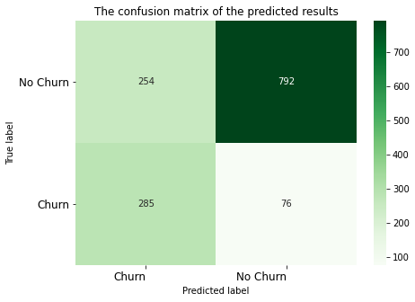

```python
plot_confusion_matrix(cm_rf)
```

### 4. Model improvement

#### 4.1 Regularzation for logistic regression

```python
# train with original data
clf_lr_reg = LogisticRegression(penalty = 'l2', C=2.0, random_state=0).fit(X_train, y_train)
y_pred_reg = clf_lr_reg.predict(X_test)
cm_lr_reg = confusion_matrix(y_test, y_pred_reg, labels=[1,0])
y_score_reg = clf_lr_reg.decision_function(X_test)
fpr_lr_reg, tpr_lr_reg, auc_thresholds_reg = roc_curve(y_test, y_score_reg)

print("Accuracy Score:", accuracy_score(y_test, y_pred_reg))
print("Recall Score:", recall_score(y_test, y_pred_reg, labels=[1,0]))
print("Precision Score:", precision_score(y_test, y_pred_reg, labels=[1,0]))
print("F1 Score:", f1_score(y_test, y_pred_reg, labels=[1,0]))
```

```
Accuracy Score: 0.8059701492537313
Recall Score: 0.5761772853185596
Precision Score: 0.6341463414634146
F1 Score: 0.6037735849056605
```

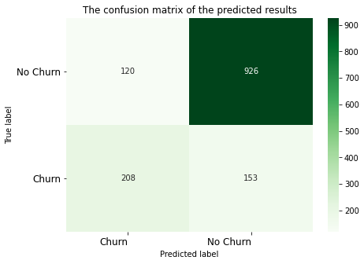

```python
plot_confusion_matrix(cm_lr_reg)
```

```
The area under ROC curve is 0.8563714559620346.
```

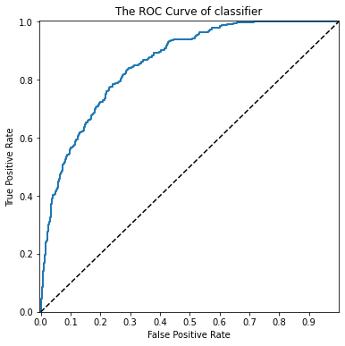

```python
plot_roc_curve(fpr_lr_reg,tpr_lr_reg)
```

#### 4.2 Grid search for K-NN

#### According to accuracy

```python
X = customer_data_scaled.drop(columns="Churn")
y = customer_data_scaled["Churn"]
k_range = range(1, 100)
k_scores = []

for k in k_range:
    knn = KNeighborsClassifier(n_neighbors=k)
    scores = cross_val_score(knn, X, y, cv=10, scoring='accuracy')
    k_scores.append(scores.mean())
print(k_scores)
```

```
[0.7204146292962083, 0.7464447281059122, 0.7464433137130505, 0.7636522408726356, 0.7637952960321381, 0.7704774935038092, 0.7687701209905158, 0.7706179242363452, 0.7704742594545226, 0.7713305761825499, 0.7743149445452078, 0.7790089126437811, 0.779720352253247, 0.7800046446428026, 0.7770188624629414, …
```

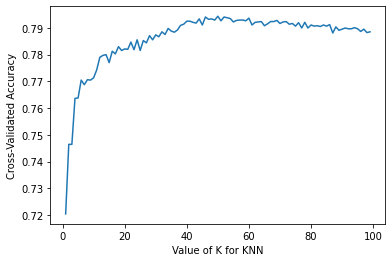

```python
plt.plot(k_range, k_scores)
plt.xlabel('Value of K for KNN')
plt.ylabel('Cross-Validated Accuracy')
```

```python
max_index = np.argmax(k_scores)
k_scores[max_index]
print('The best k is {} if we set the accuracy as our prime goal, and the corresponding accuracy is {}.'.format(max_index,k_scores[max_index]))
```

```
The best k is 49 if we set the accuracy as our prime goal, and the corresponding accuracy is 0.7943659868001973.
```

#### According to precision

```
The best k is 45 if we set the precision as our prime goal, and the corresponding precision is 0.6248946777841929.
```

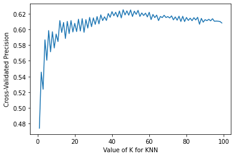

```python
k_range = range(1, 100)
k_scores = []

for k in k_range:
    knn = KNeighborsClassifier(n_neighbors=k)
    scores = cross_val_score(knn, X, y, cv=10, scoring='precision')
    k_scores.append(scores.mean())
#print(k_scores)
plt.plot(k_range, k_scores)
plt.xlabel('Value of K for KNN')
plt.ylabel('Cross-Validated Precision')
max_index = np.argmax(k_scores)
k_scores[max_index]
print('The best k is {} if we set the precision as our prime goal, and the corresponding precision is {}.'.format(max_index,k_scores[max_index]))
```

#### 4.3 Cross validation for random forest

```python
# define parameters' grid
parameters_grid = {}
parameters_grid['n_estimators'] = [50,100,150]
parameters_grid['criterion'] = ['gini', 'entropy']
parameters_grid['max_depth'] = [int(i) for i in range(5, 20, 5)]
parameters_grid['min_samples_split'] = [2]
parameters_grid['min_samples_leaf'] = [4, 6, 8]
parameters_grid['max_features'] = ['log2']
parameters_grid
```

```
{'n_estimators': [50, 100, 150],
 'criterion': ['gini', 'entropy'],
 'max_depth': [5, 10, 15],
 'min_samples_split': [2],
 'min_samples_leaf': [4, 6, 8],
 'max_features': ['log2']}
```

```python
# define model and grid search engine
improvedClassifier = RandomForestClassifier(bootstrap=True, oob_score=True, class_weight='balanced', n_jobs=-1, random_state=10)
parameters_grid_search = GridSearchCV(estimator = improvedClassifier, param_grid = parameters_grid, cv = 8, n_jobs = -1,
                                          return_train_score=True, error_score = np.nan, scoring = make_scorer(f1_score, greater_is_better=True), iid=False)
_ = parameters_grid_search.fit(X_train, y_train)
```

```python
# best parameters
parameters_grid_search.best_params_
```

```
{'criterion': 'gini',
 'max_depth': 10,
 'max_features': 'log2',
 'min_samples_leaf': 8,
 'min_samples_split': 2,
 'n_estimators': 150}
```

```python
# CV results
cv_results = parameters_grid_search.cv_results_
idx = parameters_grid_search.best_index_
train_list = []
test_list = []
for i in range(8):
    test = cv_results['split{}_test_score'.format(i)][idx]
    train = cv_results['split{}_train_score'.format(i)][idx]
    print('Split-{0:d} train F1 score: {1:.2f} validation F1 score: {2:.2f}'.format(i+1, train, test))
    train_list.append(train)
    test_list.append(test)
print('Average train F1 score: {0:.2f}±{1:.2f} validation F1 score: {2:.2f}±{3:.2f}'.format
      (np.mean(train_list), np.std(train_list), np.mean(test_list), np.std(test_list)))
```

```
Split-1 train F1 score: 0.70 validation F1 score: 0.65
Split-2 train F1 score: 0.70 validation F1 score: 0.63
Split-3 train F1 score: 0.70 validation F1 score: 0.63
Split-4 train F1 score: 0.70 validation F1 score: 0.65
Split-5 train F1 score: 0.71 validation F1 score: 0.65
Split-6 train F1 score: 0.70 validation F1 score: 0.62
Split-7 train F1 score: 0.70 validation F1 score: 0.64
Split-8 train F1 score: 0.69 validation F1 score: 0.67
Average train F1 score: 0.70±0.00 validation F1 score: 0.64±0.02
```